# Week 2 Experimenting with Seq Data

Carisa Zeng

2022-06-21

For the first practice, I’ll start with RNA-seq data and compare the data analysis using DESeq2.

First, I’ll use the `airway` data as the example.

```r
library(airway)
data(airway)
```

```r
#colData(airway)
```

```r
#head(assay(airway))
```

There are in total 8 samples.

Let’s try histogram plots on the samples. First, we need to identify the data.

```r
library(ggplot2)
```

Because airway is a S4 object, it can be a bit confusing to identify what exactly to plot. To make my live more easier, I’ll do some data transformation before making the plots.

The caveat: ggplot2 takes in dataframe.

```r
fc1 = airway@assays$data$counts#try extract the first 5 genes
colnames(fc1) = airway@colData$SampleName

fc1 = as.data.frame(fc1)
#fc1
```

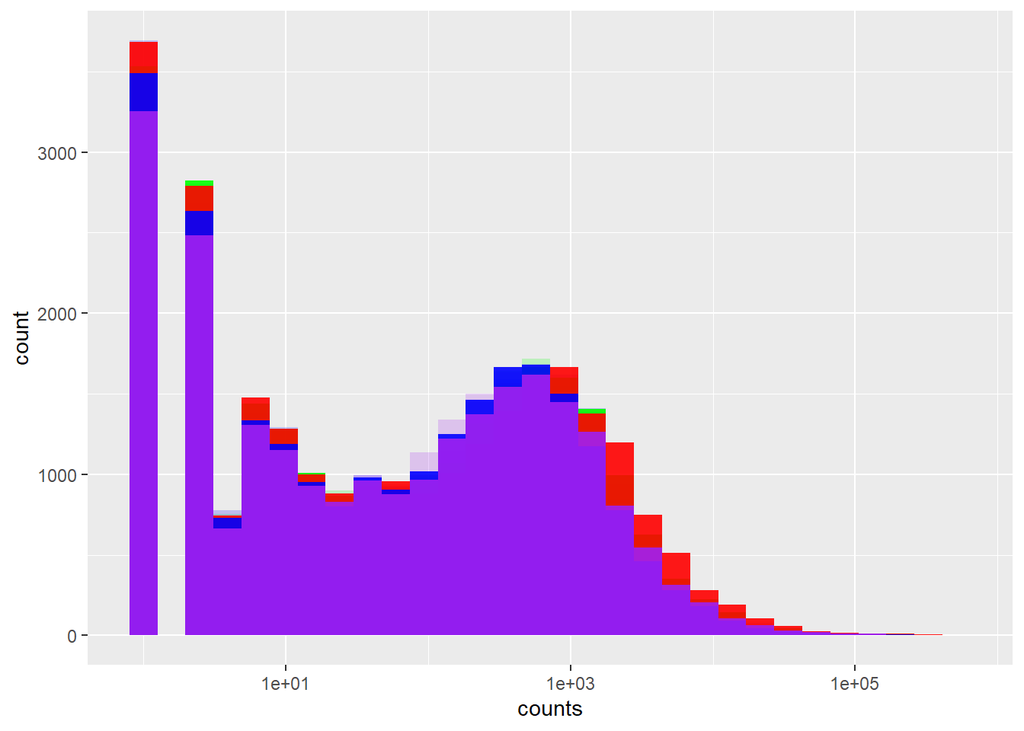

```r
ggplot() +
  geom_histogram(data = fc1,mapping = aes(x = GSM1275862),fill = "green",alpha = 0.2) +
  geom_histogram(data = fc1,mapping = aes(x = GSM1275863),fill = "red", alpha = 0.2) +
  geom_histogram(data = fc1,mapping = aes(x = GSM1275866),fill = "blue", alpha = 0.2) +
  geom_histogram(data = fc1,mapping = aes(x = GSM1275867),fill = "purple", alpha = 0.2) +
  geom_histogram(data = fc1,mapping = aes(x = GSM1275870),fill = "green", alpha = 0.9) +
  geom_histogram(data = fc1,mapping = aes(x = GSM1275871),fill = "red", alpha = 0.9) +
  geom_histogram(data = fc1,mapping = aes(x = GSM1275874),fill = "blue", alpha = 0.9) +
  geom_histogram(data = fc1,mapping = aes(x = GSM1275875),fill = "purple", alpha = 0.9) +
   xlab("counts")+
  scale_x_continuous(trans = "log10")
```

The plot don’t work well here because there are many genes with 0 counts.

Next, I’ll try plotting heatmaps. Since heatmaps are plotted to show correlations, analysis needs to take place before plotting (Otherwise, the heatmap may not be informative. Specifically, we have to select genes for making heatmaps. If the genes are not selected based on some analysis, it is likely to get mosaics). DESeq2 method typically use a funbction called `pheatmap`.

The DESeq2 analysis

```r
library(airway)
library(Rsamtools)
```

```r
dir <- system.file("extdata", package="airway", mustWork=TRUE)
csv.file <- file.path(dir, "sample_table.csv")
sample.table <- read.csv(csv.file, row.names=1)
bam.files <- file.path(dir, paste0(sample.table$Run, "_subset.bam"))
gtf.file <- file.path(dir, "Homo_sapiens.GRCh37.75_subset.gtf")
bam.list <- BamFileList(bam.files)
library(GenomicFeatures)
txdb <- makeTxDbFromGFF(gtf.file, format="gtf")
```

```
## Import genomic features from the file as a GRanges object ...
```

```
## OK
```

```
## Prepare the 'metadata' data frame ... OK
## Make the TxDb object ...
```

```
## OK
```

```r
exons.by.gene <- exonsBy(txdb, by="gene")
```

```r
library(GenomicAlignments)
se <- summarizeOverlaps(exons.by.gene, bam.list,
                        mode="Union",
                        singleEnd=FALSE,
                        ignore.strand=TRUE,
                        fragments=TRUE)
colData(se) <- DataFrame(sample.table)
library(Rsubread)
fc <- featureCounts(bam.files, annot.ext=gtf.file,
                    isGTFAnnotationFile=TRUE,
                    isPaired=TRUE)
```

[output not shown]

[output cut: 38 more lines]

[output not shown]

```r
library(DESeq2)
dds <- DESeqDataSet(airway, design= ~ cell + dex)
colnames(fc$counts) <- NULL
dds.fc <- DESeqDataSetFromMatrix(fc$counts,
                                 colData=sample.table,
                                 design=~ cell + dex)
design(dds)
```

```
## ~cell + dex
```

```r
levels(dds)
```

```r
dds$dex <- relevel(dds$dex, "untrt")
levels(dds$dex)
```

```
## [1] "untrt" "trt"
```

```r
dds <- DESeq(dds)
res <- results(dds)
```

```r
res2 <- results(dds, alpha=0.05)
resSort <- res2[order(res2$padj),]
```

```r
rld <- rlog(dds, blind=FALSE)
```

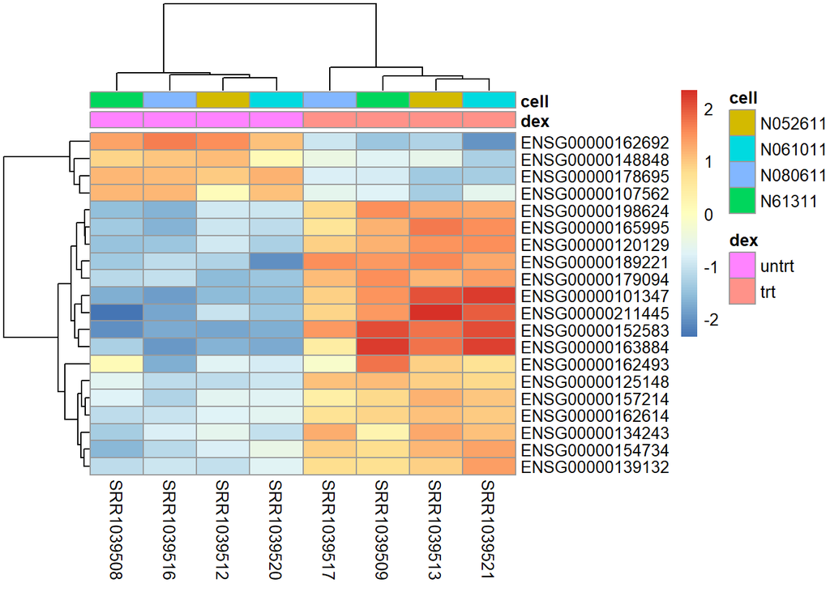

```r
library(pheatmap)
topgenes <- head(rownames(resSort),20)
mat <- assay(rld)[topgenes,]
mat <- mat - rowMeans(mat)
df <- as.data.frame(colData(dds)[,c("dex","cell")])
pheatmap(mat, annotation_col=df)
```

```r
#This
x <- LETTERS[1:20]
y <- paste0("var", seq(1,20))
data <- expand.grid(X=x, Y=y)
data$Z <- runif(400, 0, 5)
data
```

```
##     X     Y           Z
## 1   A  var1 3.251950915
## 2   B  var1 4.349200433
## 3   C  var1 3.566210127
## 4   D  var1 0.672474498
## 5   E  var1 0.004483360
## 6   F  var1 4.090141591
## 7   G  var1 2.808488919
## 8   H  var1 4.989086317
## 9   I  var1 3.721448405
## 10  J  var1 4.729477824
## 11  K  var1 1.428511033
## 12  L  var1 2.517888178
## 13  M  var1 1.898040443
## 14  N  var1 3.098415750
```

[output cut: 386 more lines]

```r
x = dds@colData@rownames
y = topgenes
mat <- assay(rld)[topgenes,]
mat <- mat - rowMeans(mat)
#These are what we want to analyze, but ggplot2 takes in n by 3 data frame.
```

We need to do some extra stuff.

```r
Y = rep(topgenes,8)#repeat the list of  topgenes for 8 times, each repeat correspond to 1 sample.
#Now I need to create a new X with  repeated sample names.
X1 = rep(x[1],20)
X2 = rep(x[2],20)
X3 = rep(x[3],20)
X4 = rep(x[4],20)
X5 = rep(x[5],20)
X6 = rep(x[6],20)
X7 = rep(x[7],20)
X8 = rep(x[8],20)
X = append(X1,X2)
X = append(X,X3)
X = append(X,X4)
X = append(X,X5)
X = append(X,X6)
X = append(X,X7)
X = append(X,X8)
```

Now I have the X and Y, and I need to create the fold change vector. Since samples are first repeated, I will iterate over rows then iterate over the columns (setting the column index as the outerloop). (For loop does not work well with R, so ideally I should use functions to do iterative work)

```r
Z = vector(length=160)
idx = 1 #use a separate counter
for (j in 1:8){ #usually we tend to do [i,j]
  for (i in 1:20){
    Z[idx] = mat[i,j]
    idx = idx + 1 #This is where I really hope ++ can work
  }
}
```

```r
#Z
```

Now I need to combine X, Y, Z into a dataframe.

```r
DATA = cbind(X,Y)
DATA = as.data.frame(DATA)#For tidyverse, I think there are other functions that can do similar work.
DATA = cbind(DATA,Z)
```

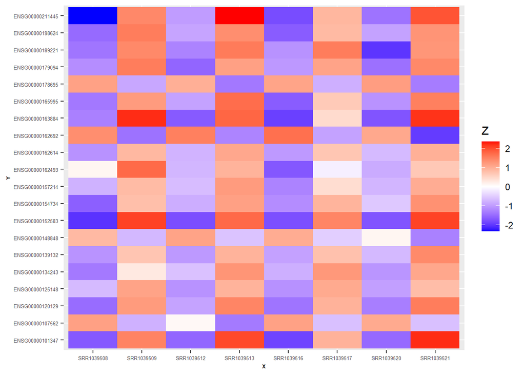

```r
ggplot(DATA, aes(X,Y,fill = Z)) +
  geom_tile()+
  scale_fill_gradient2(low="blue", high="red")+
  theme(axis.text=element_text(size=5),
        axis.title=element_text(size=5,face="bold"))
```

This still don’t look right because the data are not properly clustered. The clustering can be made based on specific levels and see how the heatmap may look like. I’ll do clustering based on `dex` because I don’t know hot to handle multiple levels. So I need to append another column to `DATA`.

There is one post on plotting dendrograms and heatmap:https://jcoliver.github.io/learn-r/008-ggplot-dendrograms-and-heatmaps.html

(I’m starting to think why would I be obessed with making clustered ggplot2 heatmap when this can be done with a few lines of code using `pheatmap`. Maybe this will get me to appreciate the efforts people put into writing packages).

```r
#df <- as.data.frame(colData(dds)[,c("dex")])
```

```r
group = vector(length = 160)
group[DATA$X == x[1]] = "untrt"
group[DATA$X == x[2]] = "trt"
group[DATA$X == x[3]] = "untrt"
group[DATA$X == x[4]] = "trt"
group[DATA$X == x[5]] = "untrt"
group[DATA$X == x[6]] = "trt"
group[DATA$X == x[7]] = "untrt"
group[DATA$X == x[8]] = "trt"
DATA = cbind(DATA,group)
```

```r
#DATA2 = DATA
#DATA2$X = factor(DATA2$X, levels = DATA2$X[order(DATA2$`as.factor(group)`)])
```

```r
# ord <- hclust( dist(data$Z))$order
# DATA$Y <- factor( DATA$Y, levels = DATA$Y, labels = seq_along(DATA$Y) )
# DATA$X <- factor( DATA$X, levels = DATA$X[ord],  labels = DATA$X)
#DATA2 = DATA
#DATA2$X = factor(DATA2$X, levels = group)
```

```r
# ggplot(DATA2, aes(reorder(X,`as.factor(group)`),Y,fill = Z)) +
#   geom_tile()+
#   scale_fill_gradient2(low="blue", high="red")+
#   theme(axis.text=element_text(size=5),
#         axis.title=element_text(size=5,face="bold"))
```

I’ll do an experiment on `melt`

```r
library(reshape2)
```

```r
pd = as.data.frame(scale(t(mat)))
pd$Sample <- rownames(pd)
pd.m <- melt(pd)#I don't think melt is doing the right thing...
```